# ES207 HW7 Anna Fryjoff-Hung

# Using the Bay Delta WQ dataset:

## 1. For the Water Years 2005-2012, develop a predictive model of the mean monthly Chl-a concentration in the California Bay Delta using other mean monthly water quality variables.

• Be sure to show your work, including multiple model comparison (or step models), provide quantification and explain the reasoning behind your final model selection. • Which variables are highly correlated with the others? How did you account for this? • Be sure to demonstrate that you have accounted for all assumptions in your regression. Identify any badly fitted observations, discuss whether your residuals are following expected patterns, and discuss whether there are any possible explanations for any poorly modeled observations. • Quantify how much variance in mean monthly Chl-a is explained by the variables you selected.

```r
require(tidyverse)
require(readr)
library(data.table)
library(lubridate)
require(readxl)
require(broom)
require(car)
```

```r
#Read in data
wq <- read_csv("/Users/Anna/Box Sync/Spring 2018/ES207/HW/HW7/Data/BayDeltaWQ.csv", col_names = TRUE, na = c("NA", "n/p"), guess_max = 30000)
```

[output not shown]

```r
#Add month and year columns to dataset and group by year/month
wq.grouped <- as.tibble(wq) %>%
  mutate(year = format(SampleDate, "%Y"), month = format(SampleDate, "%m")) %>%
  group_by(year, month) %>%
  filter(year>=2004)
wq.grouped$Depth <- as.double(wq.grouped$Depth)
wq.summary <- summarise_all(wq.grouped, mean, na.rm = TRUE)
```

[output not shown]

```r
#Add Water Year to dataset
wq.summary$year <- as.numeric(wq.summary$year)
wq.summary$month <- as.numeric(wq.summary$month)
wq.summary$WY <- ifelse(wq.summary$month>=10, wq.summary$year+1, wq.summary$year)
wq.wy <- subset(wq.summary, wq.summary$WY >= 2005 & wq.summary$WY <= 2012)
```

```r
#Stepwise Multiple Regression - pick best predictor variables from full model, choosing variables that are not all NA/make sense (avg lat/long not helpful)
lms <- step(lm(`Chlorophyll a` ~ month + Depth + `Conductance (EC)`+ SiteDepth+ Fluorescence + Oxygen + `Secchi Depth` + Temperature + Turbidity + `Ammonia (Dissolved)` + `Chloride (Dissolved)` + `Kjeldahl Nitrogen (Total)` + `Nitrite + Nitrate (Dissolved)` + `Organic Nitrogen (Dissolved)` + `Ortho-phosphate (Dissolved)` + `Pheophytin a` + `Phosphorus (Total)` + `Silica (SiO2) (Dissolved)` + `Solids (Total Dissolved)` + `Solids (Total Suspended)`, data = wq.wy))
```

```
Start:  AIC=106.11
`Chlorophyll a` ~ month + Depth + `Conductance (EC)` + SiteDepth +
    Fluorescence + Oxygen + `Secchi Depth` + Temperature + Turbidity +
    `Ammonia (Dissolved)` + `Chloride (Dissolved)` + `Kjeldahl Nitrogen (Total)` +
    `Nitrite + Nitrate (Dissolved)` + `Organic Nitrogen (Dissolved)` +
    `Ortho-phosphate (Dissolved)` + `Pheophytin a` + `Phosphorus (Total)` +
    `Silica (SiO2) (Dissolved)` + `Solids (Total Dissolved)` +
    `Solids (Total Suspended)`


Step:  AIC=106.11
`Chlorophyll a` ~ month + `Conductance (EC)` + SiteDepth + Fluorescence +
    Oxygen + `Secchi Depth` + Temperature + Turbidity + `Ammonia (Dissolved)` +
    `Chloride (Dissolved)` + `Kjeldahl Nitrogen (Total)` + `Nitrite + Nitrate (Dissolved)` +
    `Organic Nitrogen (Dissolved)` + `Ortho-phosphate (Dissolved)` +
    `Pheophytin a` + `Phosphorus (Total)` + `Silica (SiO2) (Dissolved)` +
    `Solids (Total Dissolved)` + `Solids (Total Suspended)`

                                  Df Sum of Sq    RSS    AIC
- `Chloride (Dissolved)`           1    0.0542 191.18 104.13
- `Silica (SiO2) (Dissolved)`      1    0.0852 191.21 104.15
- SiteDepth                        1    0.1250 191.25 104.17
- Fluorescence                     1    1.0186 192.15 104.62
- `Secchi Depth`                   1    1.4855 192.62 104.85
- `Nitrite + Nitrate (Dissolved)`  1    1.6390 192.77 104.92
- `Ortho-phosphate (Dissolved)`    1    2.3932 193.52 105.30
- month                            1    2.5171 193.65 105.36
- `Solids (Total Dissolved)`       1    2.5365 193.67 105.37
- `Phosphorus (Total)`             1    2.6403 193.77 105.42
- `Solids (Total Suspended)`       1    2.9445 194.07 105.57
- Turbidity                        1    2.9848 194.11 105.59
<none>                                         191.13 106.11
- `Ammonia (Dissolved)`            1    4.4280 195.56 106.30
- `Conductance (EC)`               1    6.0421 197.17 107.09
- `Organic Nitrogen (Dissolved)`   1    7.3394 198.47 107.72
- `Kjeldahl Nitrogen (Total)`      1   12.7855 203.91 110.32
- Oxygen                           1   16.9021 208.03 112.24
- `Pheophytin a`                   1   21.3930 212.52 114.29
- Temperature                      1   26.9658 218.09 116.78

```

[output cut: 214 more lines]

```
`Chlorophyll a` ~ month + `Conductance (EC)` + Oxygen + `Secchi Depth` +
    Temperature + `Kjeldahl Nitrogen (Total)` + `Organic Nitrogen (Dissolved)` +
    `Pheophytin a` + `Solids (Total Dissolved)`

                                 Df Sum of Sq    RSS     AIC
<none>                                        202.47  91.637
- `Organic Nitrogen (Dissolved)`  1     4.824 207.29  91.897
- `Secchi Depth`                  1     4.921 207.38  91.942
- month                           1     6.470 208.94  92.657
- `Kjeldahl Nitrogen (Total)`     1     8.498 210.96  93.584
- `Solids (Total Dissolved)`      1     8.901 211.37  93.767
- `Conductance (EC)`              1    10.431 212.90  94.460
- `Pheophytin a`                  1    17.764 220.23  97.711
- Oxygen                          1    21.770 224.24  99.441
- Temperature                     1    48.887 251.35 110.400
```

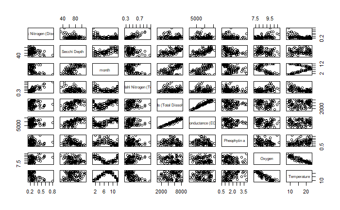

```r
#Look for correlations among influential variables - taken from model with lowest AIC
pairs(~`Organic Nitrogen (Dissolved)` + `Secchi Depth` + month + `Kjeldahl Nitrogen (Total)` + `Solids (Total Dissolved)` + `Conductance (EC)` + `Pheophytin a` + Oxygen + Temperature  , data = wq.wy)
```

```r
wy.select <- dplyr::select(wq.wy, `Chlorophyll a`,`Organic Nitrogen (Dissolved)`,`Secchi Depth`,month , `Kjeldahl Nitrogen (Total)` , `Solids (Total Dissolved)` , `Conductance (EC)` , `Pheophytin a` , Oxygen , Temperature)
cov(wy.select)
```

```
                                      year Chlorophyll a Organic Nitrogen (Dissolved)  Secchi Depth
year                            5.49473684  6.214922e-01                 -0.042040972    11.9526748
Chlorophyll a                   0.62149224  5.310594e+00                 -0.056746689    -6.0362759
Organic Nitrogen (Dissolved)   -0.04204097 -5.674669e-02                  0.011911806    -0.5123868
Secchi Depth                   11.95267484 -6.036276e+00                 -0.512386793   293.1013185
month                          -1.13684211 -1.251757e+00                 -0.144552526    36.7450060
Kjeldahl Nitrogen (Total)      -0.03845747 -6.475236e-02                  0.011653128    -0.5200913
Solids (Total Dissolved)     -284.46345889 -5.654796e+02                 -7.833458432 18532.9132675
Conductance (EC)               96.44184325 -1.594737e+03                -32.426986939 37291.5851689
Pheophytin a                   -0.29340932  9.902157e-01                 -0.008331589    -4.6192435
Oxygen                          0.08947963 -4.888614e-01                  0.035533599    -3.3388713
Temperature                     0.17635933  5.219257e+00                 -0.245457530    10.7362193
                                    month Kjeldahl Nitrogen (Total) Solids (Total Dissolved)
year                           -1.1368421              -0.038457468            -2.844635e+02
Chlorophyll a                  -1.2517571              -0.064752361            -5.654796e+02
Organic Nitrogen (Dissolved)   -0.1445525               0.011653128            -7.833458e+00
Secchi Depth                   36.7450060              -0.520091334             1.853291e+04
month                          12.0421053              -0.144334008             3.854661e+03
Kjeldahl Nitrogen (Total)      -0.1443340               0.016551914             1.366130e+01
Solids (Total Dissolved)     3854.6611158              13.661297055             3.388107e+06
Conductance (EC)             7164.2447318              12.294145498             5.993445e+06
Pheophytin a                   -0.4163727              -0.006877693            -1.454787e+02
Oxygen                         -1.3764163               0.046998028            -3.489996e+02
Temperature                     5.2447727              -0.334467637             7.463669e+02
                             Conductance (EC)  Pheophytin a        Oxygen  Temperature
year                             9.644184e+01 -2.934093e-01    0.08947963    0.1763593
Chlorophyll a                   -1.594737e+03  9.902157e-01   -0.48886142    5.2192573
Organic Nitrogen (Dissolved)    -3.242699e+01 -8.331589e-03    0.03553360   -0.2454575
Secchi Depth                     3.729159e+04 -4.619243e+00   -3.33887132   10.7362193
month                            7.164245e+03 -4.163727e-01   -1.37641629    5.2447727
Kjeldahl Nitrogen (Total)        1.229415e+01 -6.877693e-03    0.04699803   -0.3344676
Solids (Total Dissolved)         5.993445e+06 -1.454787e+02 -348.99964146  746.3669175
Conductance (EC)                 1.146090e+07 -4.371914e+02 -636.37206030 1111.0203577
Pheophytin a                    -4.371914e+02  5.189096e-01   -0.08185008    1.1383129
Oxygen                          -6.363721e+02 -8.185008e-02    0.62130613   -3.1920192
Temperature                      1.111020e+03  1.138313e+00   -3.19201923   19.7652227
```

```r
cor(wy.select)
```

```
                                    year Chlorophyll a Organic Nitrogen (Dissolved) Secchi Depth
year                          1.00000000     0.1150511                  -0.16432760    0.2978398
Chlorophyll a                 0.11505109     1.0000000                  -0.22562135   -0.1529990
Organic Nitrogen (Dissolved) -0.16432760    -0.2256214                   1.00000000   -0.2742207
Secchi Depth                  0.29783983    -0.1529990                  -0.27422071    1.0000000
month                        -0.13975762    -0.1565299                  -0.38166794    0.6184979
Kjeldahl Nitrogen (Total)    -0.12752142    -0.2184037                   0.82990734   -0.2361275
Solids (Total Dissolved)     -0.06592869    -0.1333113                  -0.03899296    0.5881068
Conductance (EC)              0.01215298    -0.2044128                  -0.08776240    0.6434172
Pheophytin a                 -0.17376191     0.5965027                  -0.10597250   -0.3745554
Oxygen                        0.04842815    -0.2691296                   0.41304520   -0.2474218
Temperature                   0.01692287     0.5094321                  -0.50586742    0.1410560
                                  month Kjeldahl Nitrogen (Total) Solids (Total Dissolved)
year                         -0.1397576               -0.12752142              -0.06592869
Chlorophyll a                -0.1565299               -0.21840369              -0.13331125
Organic Nitrogen (Dissolved) -0.3816679                0.82990734              -0.03899296
Secchi Depth                  0.6184979               -0.23612753               0.58810682
month                         1.0000000               -0.32329081               0.60347100
Kjeldahl Nitrogen (Total)    -0.3232908                1.00000000               0.05768850
Solids (Total Dissolved)      0.6034710                0.05768850               1.00000000
Conductance (EC)              0.6098315                0.02822701               0.96180845
Pheophytin a                 -0.1665655               -0.07421178              -0.10971729
Oxygen                       -0.5032060                0.46344982              -0.24054347
Temperature                   0.3399575               -0.58476199               0.09120590
                             Conductance (EC) Pheophytin a      Oxygen Temperature
year                               0.01215298  -0.17376191  0.04842815  0.01692287
Chlorophyll a                     -0.20441283   0.59650269 -0.26912957  0.50943211
Organic Nitrogen (Dissolved)      -0.08776240  -0.10597250  0.41304520 -0.50586742
Secchi Depth                       0.64341716  -0.37455543 -0.24742181  0.14105602
month                              0.60983155  -0.16656555 -0.50320596  0.33995748
Kjeldahl Nitrogen (Total)          0.02822701  -0.07421178  0.46344982 -0.58476199
Solids (Total Dissolved)           0.96180845  -0.10971729 -0.24054347  0.09120590
Conductance (EC)                   1.00000000  -0.17927362 -0.23847836  0.07381793
Pheophytin a                      -0.17927362   1.00000000 -0.14415192  0.35543889
Oxygen                            -0.23847836  -0.14415192  1.00000000 -0.91088138
Temperature                        0.07381793   0.35543889 -0.91088138  1.00000000
```

```r
#Null regression for comparison
lm.null <- lm(`Chlorophyll a` ~ 1, data = wy.select); summary(lm.null)
```

```
Call:
lm(formula = `Chlorophyll a` ~ 1, data = wy.select)

Residuals:
    Min      1Q  Median      3Q     Max
-3.2403 -1.7221 -0.5629  0.8110 11.1228

Coefficients:
            Estimate Std. Error t value Pr(>|t|)
(Intercept)   3.7024     0.2352   15.74   <2e-16 ***
---
Signif. codes:  0 ‘***’ 0.001 ‘**’ 0.01 ‘*’ 0.05 ‘.’ 0.1 ‘ ’ 1

Residual standard error: 2.304 on 95 degrees of freedom
```

```r
#Simple Regression Chlorophyll a vs. Temperature
lm.chla.tmp <- lm(`Chlorophyll a` ~ Temperature, data = wy.select); summary(lm.chla.tmp)
```

```
Call:
lm(formula = `Chlorophyll a` ~ Temperature, data = wy.select)

Residuals:
    Min      1Q  Median      3Q     Max
-2.5746 -1.3987 -0.3991  0.6842  9.9623

Coefficients:
            Estimate Std. Error t value Pr(>|t|)
(Intercept) -0.62954    0.78167  -0.805    0.423
Temperature  0.26406    0.04601   5.740 1.15e-07 ***
---
Signif. codes:  0 ‘***’ 0.001 ‘**’ 0.01 ‘*’ 0.05 ‘.’ 0.1 ‘ ’ 1

Residual standard error: 1.994 on 94 degrees of freedom
Multiple R-squared:  0.2595,    Adjusted R-squared:  0.2516
F-statistic: 32.94 on 1 and 94 DF,  p-value: 1.154e-07
```

```r
#Simple Regression Chlorophyll a vs. Oxygen
lm.chla.o <- lm(`Chlorophyll a` ~ Oxygen, data = wy.select); summary(lm.chla.o)
```

```
Call:
lm(formula = `Chlorophyll a` ~ Oxygen, data = wy.select)

Residuals:
    Min      1Q  Median      3Q     Max
-3.0011 -1.4341 -0.3638  1.0394 10.6111

Coefficients:
            Estimate Std. Error t value Pr(>|t|)
(Intercept)  10.4919     2.5163   4.170 6.79e-05 ***
Oxygen       -0.7868     0.2904  -2.709  0.00801 **
---
Signif. codes:  0 ‘***’ 0.001 ‘**’ 0.01 ‘*’ 0.05 ‘.’ 0.1 ‘ ’ 1

Residual standard error: 2.231 on 94 degrees of freedom
Multiple R-squared:  0.07243,   Adjusted R-squared:  0.06256
F-statistic:  7.34 on 1 and 94 DF,  p-value: 0.008014
```

```r
#Simple Regression Chlorophyll a vs. Pheophytin a
lm.chla.pa <- lm(`Chlorophyll a` ~ `Pheophytin a` , data = wy.select); summary(lm.chla.pa)
```

```
Call:
lm(formula = `Chlorophyll a` ~ `Pheophytin a`, data = wy.select)

Residuals:
    Min      1Q  Median      3Q     Max
-4.9290 -0.9760 -0.3091  0.6186 10.1213

Coefficients:
               Estimate Std. Error t value Pr(>|t|)
(Intercept)      0.4458     0.4902   0.909    0.365
`Pheophytin a`   1.9083     0.2648   7.206 1.43e-10 ***
---
Signif. codes:  0 ‘***’ 0.001 ‘**’ 0.01 ‘*’ 0.05 ‘.’ 0.1 ‘ ’ 1

Residual standard error: 1.859 on 94 degrees of freedom
Multiple R-squared:  0.3558,    Adjusted R-squared:  0.349
F-statistic: 51.92 on 1 and 94 DF,  p-value: 1.426e-10
```

```r
#Simple Regression Chlorophyll a vs. Conductance (EC)
lm.chla.ec <- lm(`Chlorophyll a` ~ `Conductance (EC)` , data = wy.select); summary(lm.chla.ec)
```

```
Call:
lm(formula = `Chlorophyll a` ~ `Conductance (EC)`, data = wy.select)

Residuals:
    Min      1Q  Median      3Q     Max
-3.2771 -1.3863 -0.4452  0.5602 10.7873

Coefficients:
                     Estimate Std. Error t value Pr(>|t|)
(Intercept)         4.955e+00  6.607e-01   7.500 3.52e-11 ***
`Conductance (EC)` -1.391e-04  6.873e-05  -2.025   0.0457 *
---
Signif. codes:  0 ‘***’ 0.001 ‘**’ 0.01 ‘*’ 0.05 ‘.’ 0.1 ‘ ’ 1

Residual standard error: 2.268 on 94 degrees of freedom
Multiple R-squared:  0.04178,   Adjusted R-squared:  0.03159
F-statistic: 4.099 on 1 and 94 DF,  p-value: 0.04574
```

```r
#Simple Regression Chlorophyll a vs. Solids (Total Dissolved)
lm.chla.tds <- lm(`Chlorophyll a` ~ `Solids (Total Dissolved)`  , data = wy.select); summary(lm.chla.tds)
```

```
Call:
lm(formula = `Chlorophyll a` ~ `Solids (Total Dissolved)`, data = wy.select)

Residuals:
    Min      1Q  Median      3Q     Max
-3.0448 -1.4752 -0.4041  0.5809 11.1789

Coefficients:
                             Estimate Std. Error t value Pr(>|t|)
(Intercept)                 4.5571346  0.6960247   6.547 3.07e-09 ***
`Solids (Total Dissolved)` -0.0001669  0.0001280  -1.304    0.195
---
Signif. codes:  0 ‘***’ 0.001 ‘**’ 0.01 ‘*’ 0.05 ‘.’ 0.1 ‘ ’ 1

Residual standard error: 2.296 on 94 degrees of freedom
Multiple R-squared:  0.01777,   Adjusted R-squared:  0.007323
F-statistic: 1.701 on 1 and 94 DF,  p-value: 0.1954
```

```r
#Simple Regression Chlorophyll a vs. Kjeldahl Nitrogen (Total)
lm.chla.kn <- lm(`Chlorophyll a` ~ `Kjeldahl Nitrogen (Total)`  , data = wy.select); summary(lm.chla.kn)
```

```
Call:
lm(formula = `Chlorophyll a` ~ `Kjeldahl Nitrogen (Total)`, data = wy.select)

Residuals:
    Min      1Q  Median      3Q     Max
-2.7026 -1.4980 -0.3894  0.8077 11.0867

Coefficients:
                            Estimate Std. Error t value Pr(>|t|)
(Intercept)                   5.5140     0.8662   6.366 7.05e-09 ***
`Kjeldahl Nitrogen (Total)`  -3.9121     1.8029  -2.170   0.0325 *
---
Signif. codes:  0 ‘***’ 0.001 ‘**’ 0.01 ‘*’ 0.05 ‘.’ 0.1 ‘ ’ 1

Residual standard error: 2.261 on 94 degrees of freedom
Multiple R-squared:  0.0477,    Adjusted R-squared:  0.03757
F-statistic: 4.708 on 1 and 94 DF,  p-value: 0.03254
```

```r
#Simple Regression Chlorophyll a vs. month
lm.chla.m <- lm(`Chlorophyll a` ~ month   , data = wy.select); summary(lm.chla.m)
```

```
Call:
lm(formula = `Chlorophyll a` ~ month, data = wy.select)

Residuals:
    Min      1Q  Median      3Q     Max
-3.3509 -1.4822 -0.3795  0.6779 11.0709

Coefficients:
            Estimate Std. Error t value Pr(>|t|)
(Intercept)  4.37808    0.49789   8.793 6.75e-14 ***
month       -0.10395    0.06765  -1.537    0.128
---
Signif. codes:  0 ‘***’ 0.001 ‘**’ 0.01 ‘*’ 0.05 ‘.’ 0.1 ‘ ’ 1

Residual standard error: 2.288 on 94 degrees of freedom
Multiple R-squared:  0.0245,    Adjusted R-squared:  0.01412
F-statistic: 2.361 on 1 and 94 DF,  p-value: 0.1278
```

```r
#Simple Regression Chlorophyll a vs. Secchi Depth
lm.chla.sd <- lm(`Chlorophyll a` ~ `Secchi Depth`  , data = wy.select); summary(lm.chla.sd)
```

```
Call:
lm(formula = `Chlorophyll a` ~ `Secchi Depth`, data = wy.select)

Residuals:
    Min      1Q  Median      3Q     Max
-3.3245 -1.5203 -0.3163  0.9805 11.2190

Coefficients:
               Estimate Std. Error t value Pr(>|t|)
(Intercept)     5.16732    1.00350   5.149 1.43e-06 ***
`Secchi Depth` -0.02059    0.01372  -1.501    0.137
---
Signif. codes:  0 ‘***’ 0.001 ‘**’ 0.01 ‘*’ 0.05 ‘.’ 0.1 ‘ ’ 1

Residual standard error: 2.289 on 94 degrees of freedom
Multiple R-squared:  0.02341,   Adjusted R-squared:  0.01302
F-statistic: 2.253 on 1 and 94 DF,  p-value: 0.1367
```

```r
#Simple Regression Chlorophyll a vs. Organic Nitrogen (Dissolved)
lm.chla.on <- lm(`Chlorophyll a` ~ `Organic Nitrogen (Dissolved)`  , data = wy.select); summary(lm.chla.on)
```

```
Call:
lm(formula = `Chlorophyll a` ~ `Organic Nitrogen (Dissolved)`,
    data = wy.select)

Residuals:
    Min      1Q  Median      3Q     Max
-2.9029 -1.5706 -0.2607  0.7255 10.7609

Coefficients:
                               Estimate Std. Error t value Pr(>|t|)
(Intercept)                      4.9774     0.6128   8.123 1.76e-12 ***
`Organic Nitrogen (Dissolved)`  -4.7639     2.1216  -2.245   0.0271 *
---
Signif. codes:  0 ‘***’ 0.001 ‘**’ 0.01 ‘*’ 0.05 ‘.’ 0.1 ‘ ’ 1

Residual standard error: 2.257 on 94 degrees of freedom
Multiple R-squared:  0.0509,    Adjusted R-squared:  0.04081
F-statistic: 5.042 on 1 and 94 DF,  p-value: 0.02709
```

```r
#Simple Regression Chlorophyll a vs. year
lm.chla.yr <- lm(`Chlorophyll a` ~ year  , data = wy.select); summary(lm.chla.yr)
```

```
Call:
lm(formula = `Chlorophyll a` ~ year, data = wy.select)

Residuals:
    Min      1Q  Median      3Q     Max
-3.0798 -1.7742 -0.3941  1.0590 11.0380

Coefficients:
             Estimate Std. Error t value Pr(>|t|)
(Intercept) -223.4444   202.2827  -1.105    0.272
year           0.1131     0.1007   1.123    0.264

Residual standard error: 2.301 on 94 degrees of freedom
Multiple R-squared:  0.01324,   Adjusted R-squared:  0.002739
F-statistic: 1.261 on 1 and 94 DF,  p-value: 0.2643
```

```r
lms <- list(null=lm.null, chla.tmp = lm.chla.tmp, chla.o = lm.chla.o, chla.pa = lm.chla.pa, chla.ec = lm.chla.ec, chla.tds = lm.chla.tds, chla.kn = lm.chla.kn, chla.m = lm.chla.m, chla.sd = lm.chla.sd, chla.on = lm.chla.on, chla.yr = lm.chla.yr )
lms.stats <- mapply(glance, lms)
colnames(lms.stats) <- names(lms)
lms.stats
```

```
              null      chla.tmp    chla.o      chla.pa      chla.ec    chla.tds    chla.kn
r.squared     0         0.2595211   0.07243073  0.3558155    0.0417846  0.01777189  0.04770017
adj.r.squared 0         0.2516436   0.06256297  0.3489624    0.03159082 0.007322655 0.03756932
sigma         2.304473  1.993544    2.231221    1.859407     2.26778    2.29602     2.260769
statistic     NA        32.94487    7.34014     51.92092     4.099029   1.700784    4.708408
p.value       NA        1.15385e-07 0.008013767 1.426426e-10 0.04574488 0.1953699   0.03253638
df            1         2           2           2            2          2           2
logLik        -215.8612 -201.4393   -212.2522   -194.7523    -213.8125  -215.0005   -213.5152
AIC           435.7225  408.8785    430.5045    395.5046     433.625    436.0011    433.0305
BIC           440.8512  416.5716    438.1975    403.1976     441.318    443.6941    440.7235
deviance      504.5064  373.5763    467.9646    324.9952     483.4258   495.5404    480.4413
df.residual   95        94          94          94           94         94          94
              chla.m     chla.sd    chla.on    chla.yr
r.squared     0.02450161 0.0234087  0.05090499 0.01323675
adj.r.squared 0.01412397 0.01301943 0.04080824 0.002739271
sigma         2.28814    2.289422   2.256962   2.301314
statistic     2.361      2.253162   5.041718   1.260946
p.value       0.1277617  0.1366934  0.02708759 0.2643321
df            2          2          2          2
logLik        -214.6705  -214.7243  -213.3534  -215.2216
AIC           435.341    435.4485   432.7068   436.4433
BIC           443.0341   443.1416   440.3999   444.1363
deviance      492.1452   492.6965   478.8245   497.8284
df.residual   94         94         94         94
```

```r
#Based off r-squared values, choosing Temperature and Pheophytin a as good predictor variables for Chlorophyll A
lm.chla.tmp.pa <- lm(`Chlorophyll a` ~ Temperature + `Pheophytin a`, data = wy.select); summary(lm.chla.tmp.pa)
```

```
Call:
lm(formula = `Chlorophyll a` ~ Temperature + `Pheophytin a`,
    data = wy.select)

Residuals:
    Min      1Q  Median      3Q     Max
-3.6117 -0.9368 -0.3208  0.6285  9.5489

Coefficients:
               Estimate Std. Error t value Pr(>|t|)
(Intercept)    -1.78836    0.70179  -2.548   0.0125 *
Temperature     0.17646    0.04237   4.164 6.97e-05 ***
`Pheophytin a`  1.52118    0.26151   5.817 8.42e-08 ***
---
Signif. codes:  0 ‘***’ 0.001 ‘**’ 0.01 ‘*’ 0.05 ‘.’ 0.1 ‘ ’ 1

Residual standard error: 1.716 on 93 degrees of freedom
Multiple R-squared:  0.4571,    Adjusted R-squared:  0.4454
F-statistic: 39.14 on 2 and 93 DF,  p-value: 4.634e-13
```

Choosing temperature as the most important predictor variable as Pheophytin a is basically a direct measure of Chlorophyll a

## 2. Parallel Regression- Parallel regression specifies an additive model, where there is one regression line (for the continuous predictor) which is displaced vertically according to the mean value of the discrete predictor. It hypothesizes that the only effect of the discrete predictor is to adjust the mean, but that the relation between the continuous predictor and the response variable is then the same for all classes of the discrete predictor.

Using your mean monthly water quality dataset for CA WY 2005-2012, create a new discrete value called “season”, and assign a label to your data for “wet season” and “dry season” (you will have decide what constitutes wet and dry). Model the mean monthly Chl-a concentration as a function of season and the water quality variable you idenitifed as MOST important in explaining the variance of Chl-a from question 1.

• Model them first separately, then as an additive model, e.g.: o lm(Chl-a ~ season) o lm(Chl-a ~ my_most_important_variable) o lm(Chl-a ~ season + my_most_important_variable) • How much of the variation in Chl-a is explained by season? By your most important variable? By both together? Is the combined model better than individual models? • In the parallel regression model (season and your most important variable as predictors), what are the differences in the means between seasons? What is the slope of the linear regression after accounting for season? How does this compare with the slope of the linear regression not considering season? • Are the residuals normally distributed? • Plot Chl-a vs your most important variable, with the observations colored by season. Add the parallel regression lines from the combined model in the appropriate colors, and add the univariate regression line.

```r
#Add season for column and differentiate between wet/dry
wy.select$season <- ifelse(wy.select$month >=10|wy.select$month<=3, "wet", "dry")
```

```r
#lm(Chl-a ~ season)
lm.chla.season <- lm(`Chlorophyll a` ~ season, data = wy.select); summary(lm.chla.season)
```

```
Call:
lm(formula = `Chlorophyll a` ~ season, data = wy.select)

Residuals:
    Min      1Q  Median      3Q     Max
-2.4960 -0.9895 -0.5710  0.5378  9.8236

Coefficients:
            Estimate Std. Error t value Pr(>|t|)
(Intercept)   5.0017     0.2755  18.155  < 2e-16 ***
seasonwet    -2.5985     0.3896  -6.669 1.75e-09 ***
---
Signif. codes:  0 ‘***’ 0.001 ‘**’ 0.01 ‘*’ 0.05 ‘.’ 0.1 ‘ ’ 1

Residual standard error: 1.909 on 94 degrees of freedom
Multiple R-squared:  0.3212,    Adjusted R-squared:  0.314
F-statistic: 44.48 on 1 and 94 DF,  p-value: 1.751e-09
```

```r
#lm(Chl-a ~ my_most_important_variable)
lm.chla.tmp <- lm(`Chlorophyll a` ~ Temperature, data = wy.select); summary(lm.chla.tmp)
```

```
Call:
lm(formula = `Chlorophyll a` ~ Temperature, data = wy.select)

Residuals:
    Min      1Q  Median      3Q     Max
-2.5746 -1.3987 -0.3991  0.6842  9.9623

Coefficients:
            Estimate Std. Error t value Pr(>|t|)
(Intercept) -0.62954    0.78167  -0.805    0.423
Temperature  0.26406    0.04601   5.740 1.15e-07 ***
---
Signif. codes:  0 ‘***’ 0.001 ‘**’ 0.01 ‘*’ 0.05 ‘.’ 0.1 ‘ ’ 1

Residual standard error: 1.994 on 94 degrees of freedom
Multiple R-squared:  0.2595,    Adjusted R-squared:  0.2516
F-statistic: 32.94 on 1 and 94 DF,  p-value: 1.154e-07
```

```r
#lm(Chl-a ~ season + my_most_important_variable)
lm.chla.season.tmp <- lm(`Chlorophyll a` ~ season + Temperature, data = wy.select); summary(lm.chla.season.tmp)
```

```
Call:
lm(formula = `Chlorophyll a` ~ season + Temperature, data = wy.select)

Residuals:
    Min      1Q  Median      3Q     Max
-2.4751 -1.0508 -0.4941  0.4897  9.7273

Coefficients:
            Estimate Std. Error t value Pr(>|t|)
(Intercept)  3.12227    1.37288   2.274  0.02525 *
seasonwet   -1.95618    0.60137  -3.253  0.00159 **
Temperature  0.09499    0.06799   1.397  0.16572
---
Signif. codes:  0 ‘***’ 0.001 ‘**’ 0.01 ‘*’ 0.05 ‘.’ 0.1 ‘ ’ 1

Residual standard error: 1.899 on 93 degrees of freedom
Multiple R-squared:  0.3352,    Adjusted R-squared:  0.3209
F-statistic: 23.44 on 2 and 93 DF,  p-value: 5.705e-09
```

```r
var.chla.tmp <- var(wy.select$`Chlorophyll a`, wy.select$Temperature)
var.chla.tmp
```

```
[1] 5.219257
```